# EDA Prosper Loan Data Analyzed by Costa Stamatinos

#### Summary of the Sample:

This is a summary of the first nine variables.

```
##                    ListingKey   ListingNumber     ListingCreationDate
##  1DC23600201690400A1833D:   2   Min.   :     60   Min.   :2005-12-29
##  413D35956728417628620AB:   2   1st Qu.: 393557   1st Qu.:2008-09-05
##  6DD335946686190621E4C96:   2   Median : 600068   Median :2012-06-14
##  6FF23586561364692709E44:   2   Mean   : 626722   Mean   :2011-07-03
##  75CC35913009376639E1A6B:   2   3rd Qu.: 890208   3rd Qu.:2013-09-07
##  781A3598846008354DF07F7:   2   Max.   :1250718   Max.   :2014-03-09
##  (Other)                :9988
##   CreditGrade        Term                       LoanStatus
##  C      : 494   Min.   :12.00   Current              :4962
##  D      : 461   1st Qu.:36.00   Completed            :3332
##  B      : 381   Median :36.00   Chargedoff           :1071
##  AA     : 323   Mean   :40.88   Defaulted            : 442
##  HR     : 303   3rd Qu.:36.00   Past Due (1-15 days) :  73
##  (Other): 615   Max.   :60.00   Past Due (61-90 days):  30
##  NA's   :7423                   (Other)              :  90
##    ClosedDate          BorrowerAPR      BorrowerRate
##  Min.   :2006-04-04   Min.   :0.0165   Min.   :0.0000
##  1st Qu.:2009-07-04   1st Qu.:0.1546   1st Qu.:0.1333
##  Median :2011-03-28   Median :0.2081   Median :0.1819
##  Mean   :2011-03-02   Mean   :0.2181   Mean   :0.1921
##  3rd Qu.:2013-01-26   3rd Qu.:0.2819   3rd Qu.:0.2499
##  Max.   :2014-03-10   Max.   :0.4135   Max.   :0.4000
##  NA's   :5154         NA's   :1
```

#### Duplicates and Exploring Loaners

Checking for duplicates in member keys. Member keys variable definition: The unique key that is associated with the borrower.

Creating a data frame of the top loaner to explore the multiple loaners data.

Creating a loners data frame and adding the IsLoaner to the sample.

```r
#Create top loaner data frame to explore
top_loaner <- subset(samp_ldf, MemberKey == "5AD03382187155131B956C2")
top_loaner <- arrange(top_loaner, c(ListingCreationDate))

#Create a data frame subset of only people with multiple loans
templist <- subset(data.frame(sort(table(samp_ldf$MemberKey), decreasing = T)),
                  Freq > 1)
loaners <- subset(samp_ldf, MemberKey %in% templist[[1]])
loaners <- arrange(loaners, loaners$MemberKey, loaners$LoanOriginationDate)

#Create a logical variable in the sample for serial loaners,  True/False
samp_ldf$IsLoaner <- samp_ldf$MemberKey %in% loaners$MemberKey
```

The average change in Prosper rating for people who borrowed multiple times. Prosper rating variable definition: The Prosper Rating assigned at the time the listing was created: 0-N/A, 1-HR, 2-E, 3-D, 4-C, 5-B, 6-A, 7-AA.

```
## [1] 0.7123288
```

It seems that on average lenders Prosper score increased the more loans they had with Prosper. More exploration is preformed below.

#### Factors and Numerical Data

Count and fifteen of the numerical variables.

```r
#Counting then listing variables that are numeric
table(sapply(samp_ldf, is.numeric))
```

```
##
## FALSE  TRUE
##    21    61
```

```r
head(sort(sapply(samp_ldf, is.numeric), decreasing = T), n = 15)
```

```
##             ListingNumber                      Term
##                      TRUE                      TRUE
##               BorrowerAPR              BorrowerRate
##                      TRUE                      TRUE
##               LenderYield   EstimatedEffectiveYield
##                      TRUE                      TRUE
##             EstimatedLoss           EstimatedReturn
##                      TRUE                      TRUE
##   ProsperRating..numeric.              ProsperScore
##                      TRUE                      TRUE
## ListingCategory..numeric.  EmploymentStatusDuration
##                      TRUE                      TRUE
##     CreditScoreRangeLower     CreditScoreRangeUpper
##                      TRUE                      TRUE
##        CurrentCreditLines
##                      TRUE
```

## Univariate Plots Section

Single variable plots of vectors. The data on serial loaners looked interesting, and was plotted with a few variables to compare.

#### Non-Numerical Data

Summary of credit grade along with plots from the sample and loaners data frame. Credit grade variable definition: The Credit rating that was assigned at the time the listing went live. Applicable for listings pre-2009 period and will only be populated for those listings.

```
##    A   AA    B    C    D    E   HR   NC NA's
##  298  323  381  494  461  301  303   16 7423
```

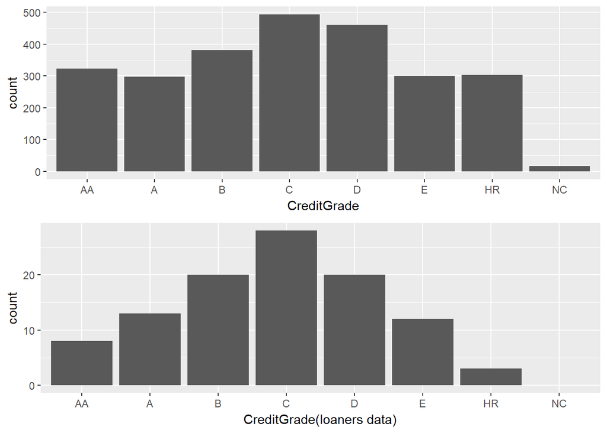

Summary of loan status along with plots from the sample and loaners data frame. Loan status variable definition: The current status of the loan: Cancelled, Chargedoff, Completed, Current, Defaulted, FinalPaymentInProgress, PastDue. The PastDue status will be accompanied by a delinquency bucket.

```
##              Cancelled             Chargedoff              Completed
##                      1                   1071                   3332
##                Current              Defaulted FinalPaymentInProgress
##                   4962                    442                     24
##   Past Due (>120 days)   Past Due (1-15 days)  Past Due (16-30 days)
##                      0                     73                     20
##  Past Due (31-60 days)  Past Due (61-90 days) Past Due (91-120 days)
##                     22                     30                     23
```

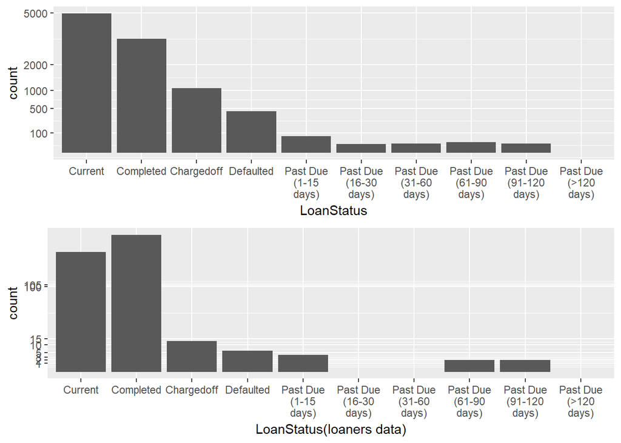

```
##
##   CA   TX   FL   NY   IL   GA   OH   MI   WA   NJ
## 1309  629  608  562  530  429  351  309  265  263
```

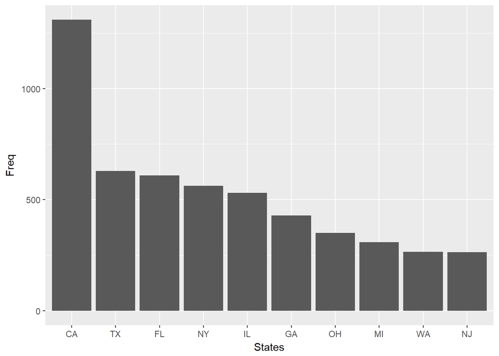

Last non numerical plots of interest.

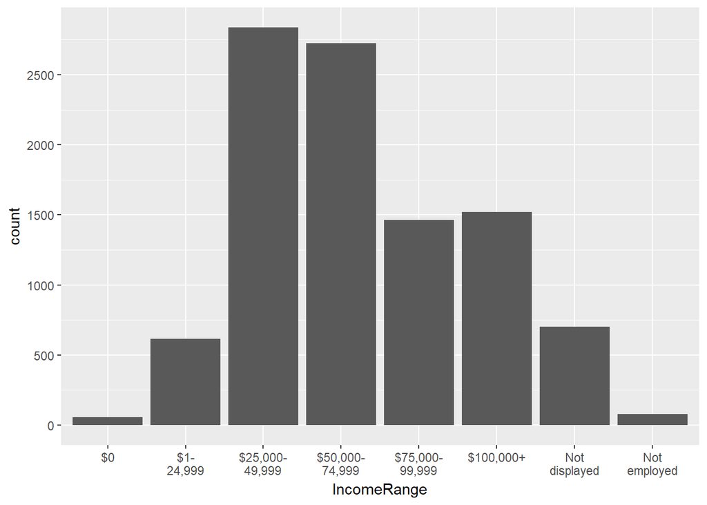

#### Numerical Data

There are a large number of numerical variables but there appear to be only a few worth lookin at. Below are summaries and plots of numerical data that might be interesting.

Summary and histogram of loan origination date.

```
##         Min.      1st Qu.       Median         Mean      3rd Qu.
## "2006-01-10" "2008-09-23" "2012-06-25" "2011-07-15" "2013-09-18"
##         Max.
## "2014-03-12"
```

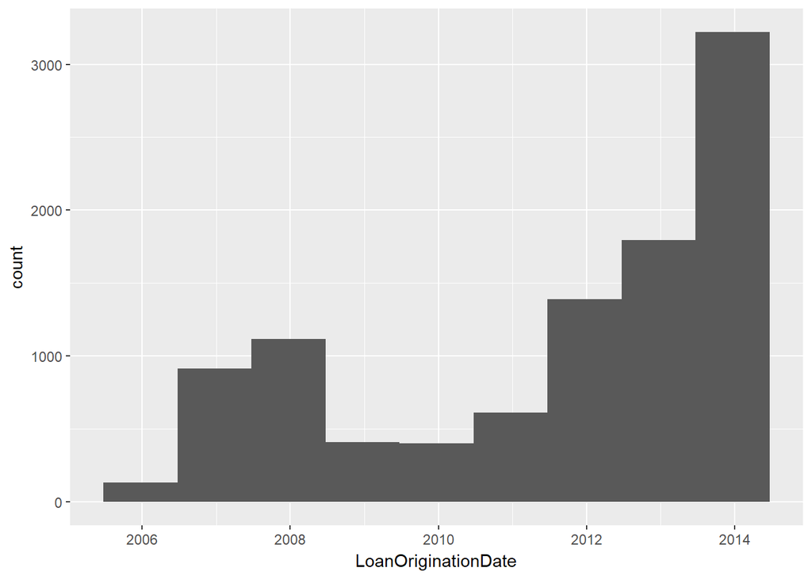

Summary and histogram of borrower rate. Borrower rate variable definition: The Borrower’s interest rate for this loan.

```
##    Min. 1st Qu.  Median    Mean 3rd Qu.    Max.
##  0.0000  0.1333  0.1819  0.1921  0.2499  0.4000
```

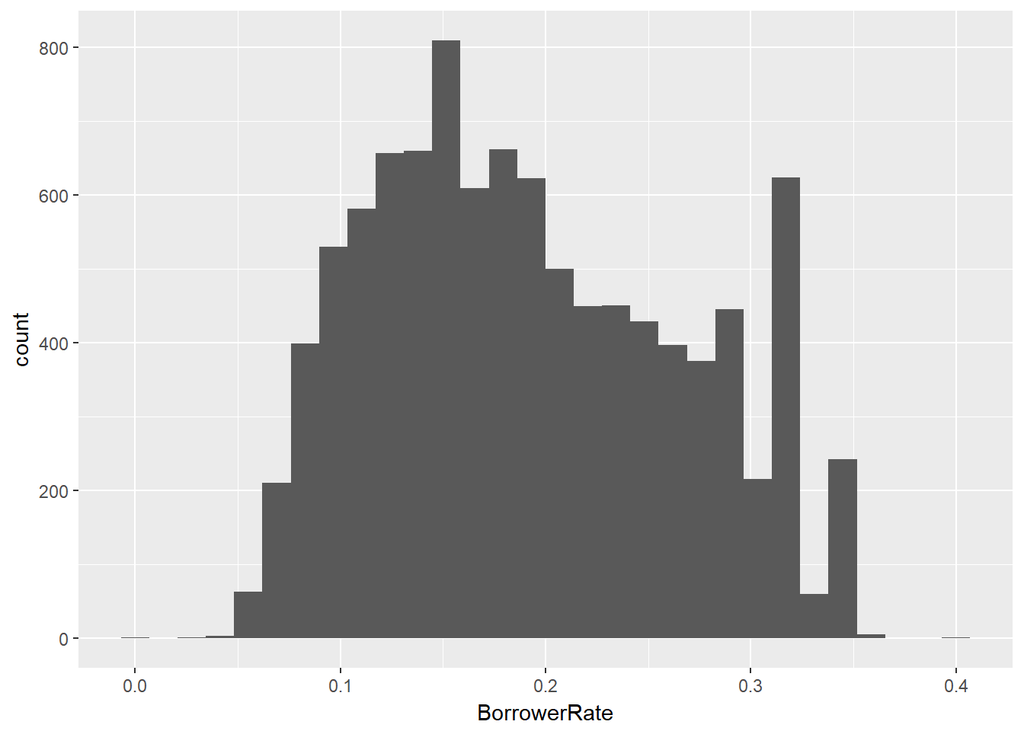

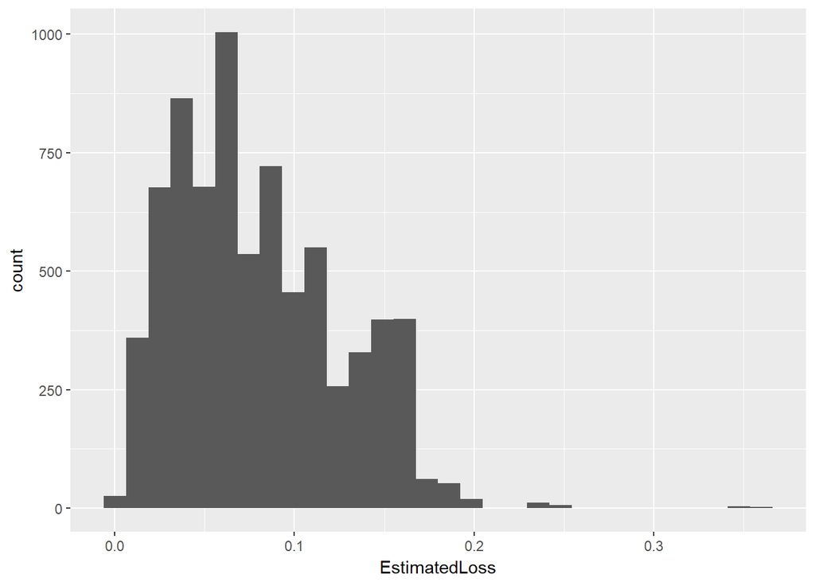

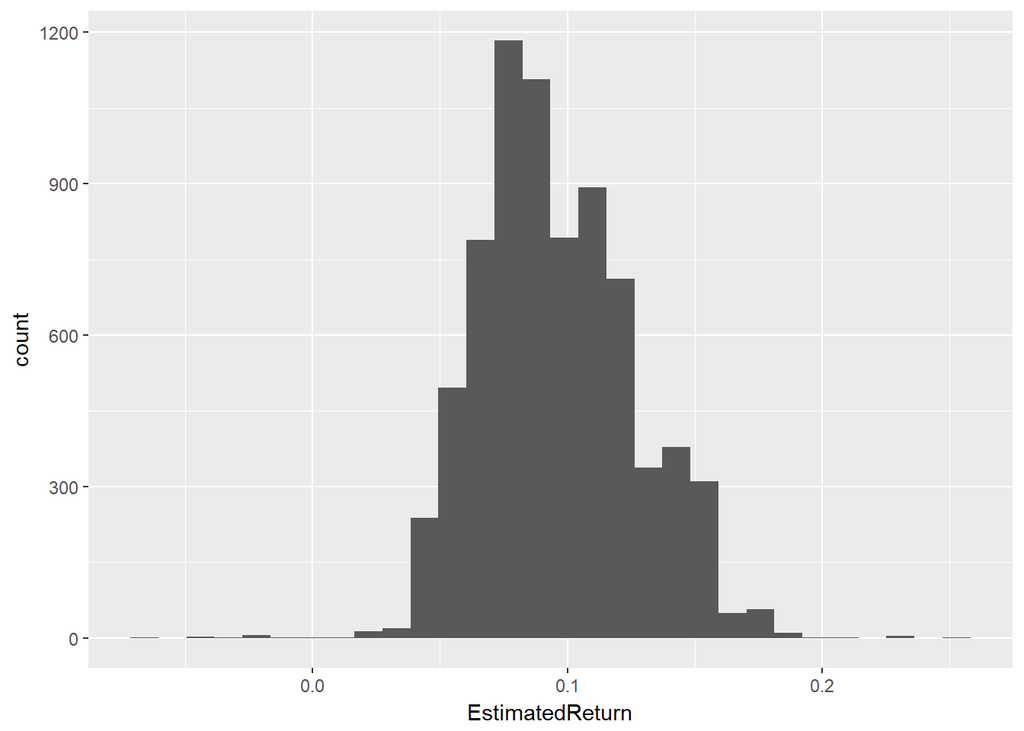

Summary and histograms of credit data.

```
##    Min. 1st Qu.  Median    Mean 3rd Qu.    Max.    NA's
##     0.0   660.0   680.0   685.2   720.0   880.0      59
```

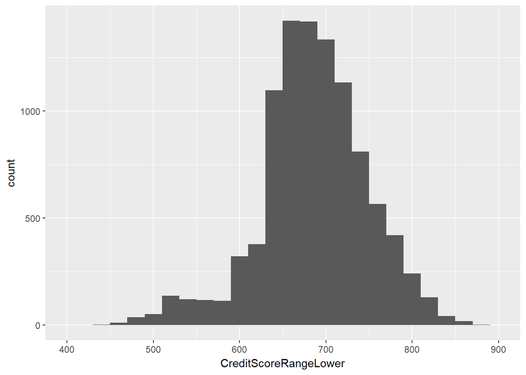

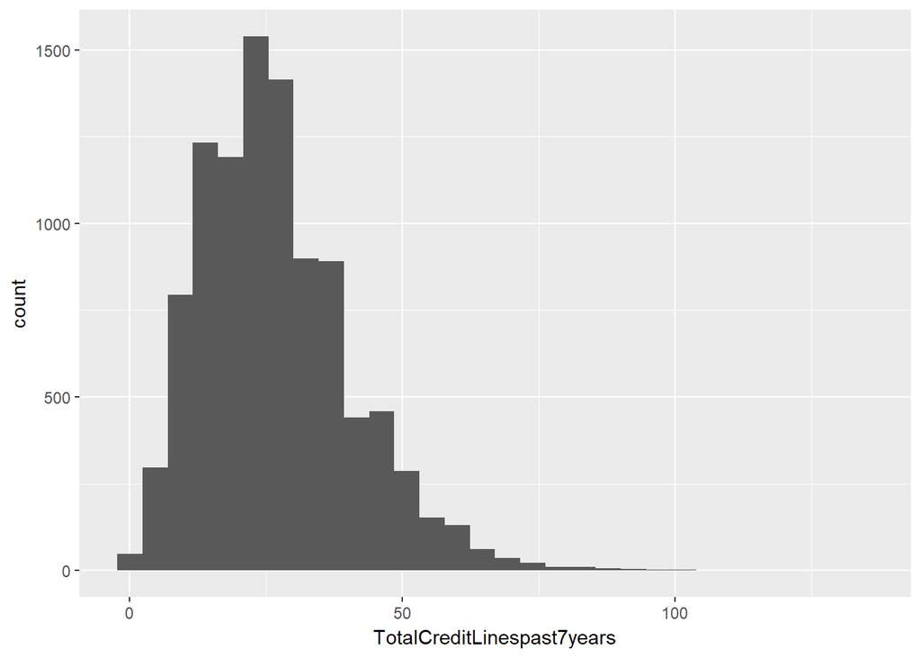

Summary and histograms of loan amounts and payments.

```
##    Min. 1st Qu.  Median    Mean 3rd Qu.    Max.
##    1000    4000    6500    8350   12000   35000
```

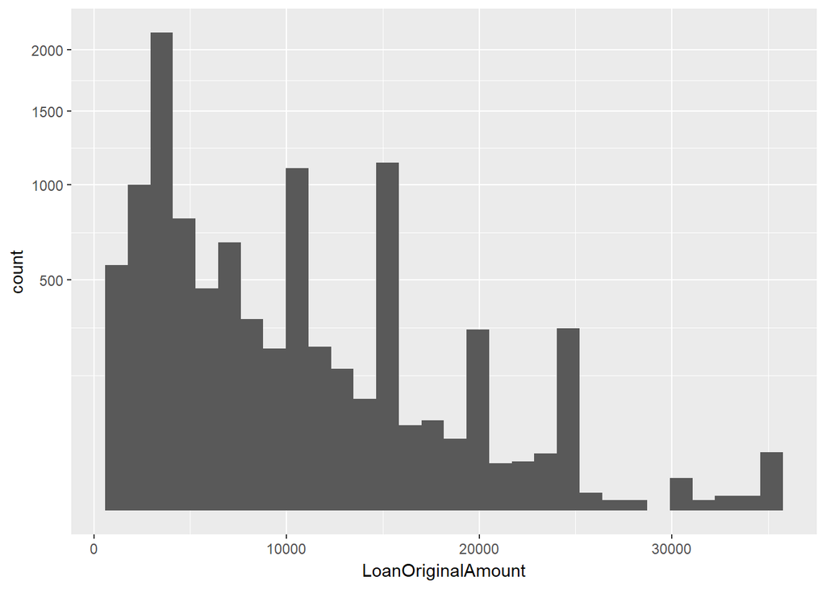

```
##    Min. 1st Qu.  Median    Mean 3rd Qu.    Max.
##     0.0   131.6   217.7   272.5   371.6  2251.5
```

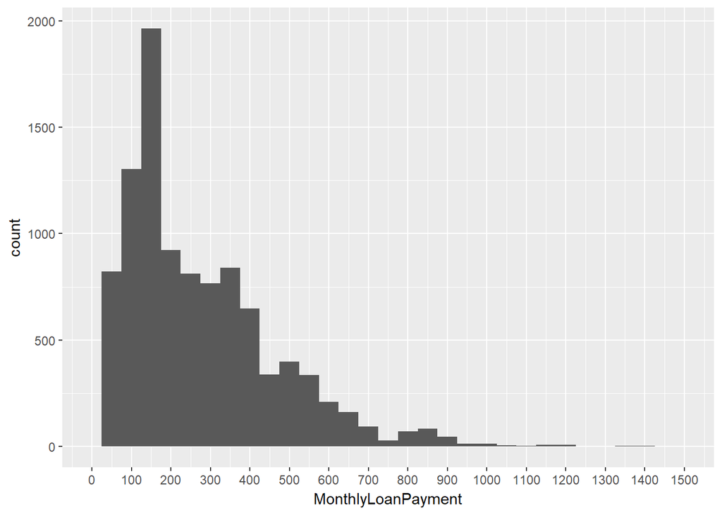

Summary and plots of income related data.

```
##    Min. 1st Qu.  Median    Mean 3rd Qu.    Max.
##       0    3242    4617    5779    6717 1750003
```

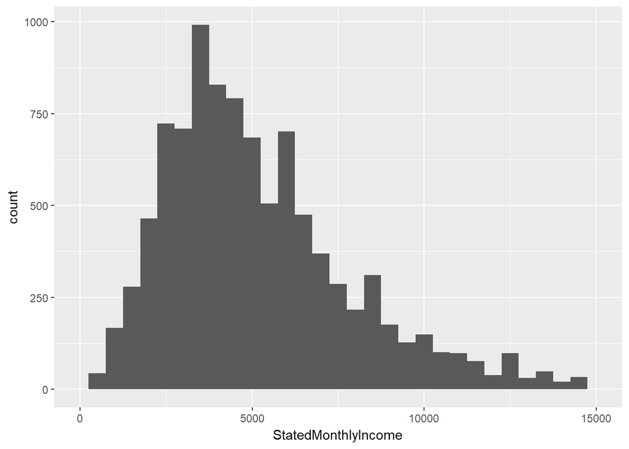

# Univariate Analysis

That is one large data set! Out of the 81 variables many were related to each other. This was the most ineresting bunch, and I can’t show all of them. With the proper tools and more time all 81 could be compared and evaluated, but I’ll stick with what i found.

### What is the structure of your dataset?

The data was in csv format originally and then tranfered to a data frame for this project. Again there are 113937 observations of 81 variables. I have listed a few of the definitions for the more obscure variables, and more can be found in the variable definition xml file with the data set. Here are a few statistics of the sample.

### What is/are the main feature(s) of interest in your dataset?

Since the data set is concerned with money, the obvious interest lies in who’s getting how much. Borrowers are interested in how much they can get and their monthy payment. Lenders are interested in how much they will get in terms of yield, return, and loss.

investigation into your feature(s) of interest? Some variables are constructed using other variables, so natural correlation will be easily visable in those. I choose ones that stand out the best visually to compare with others. Again dealing with money, numericl variables will be the place to start, but it will be interesting to see how factored variables effect the money.

### Did you create any new variables from existing variables in the dataset?

Yes, several to explore duplicates in member keys, and several to help plot interesting data.

### Of the features you investigated, were there any unusual distributions? Did you perform any operations on the data to tidy, adjust, or change the form of the data? If so, why did you do this?

Yes. The factored data especially, was arranged alphabetically or numerically instead of the disired way. Or to see changes over time for the loaners data.

# Bivariate Plots Section

Point plots of borrower rate vs lender yield and estimated yield.

[figure not shown]

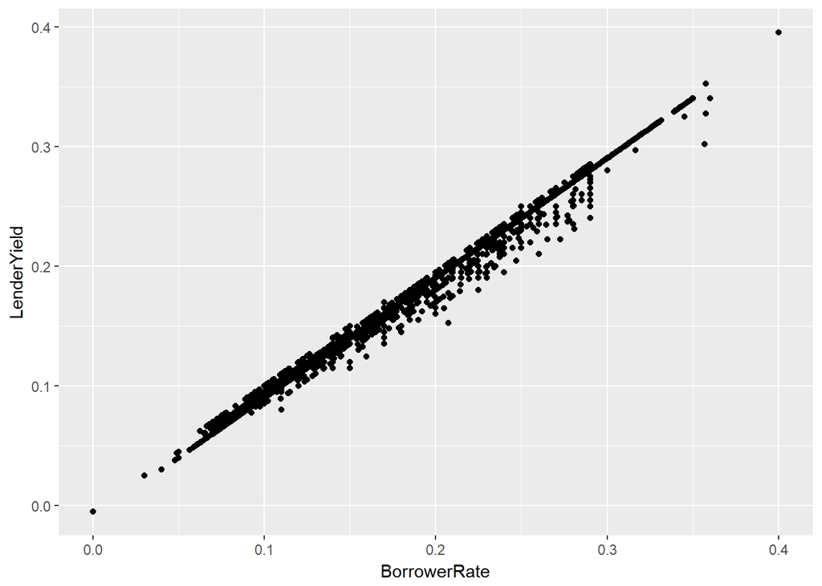

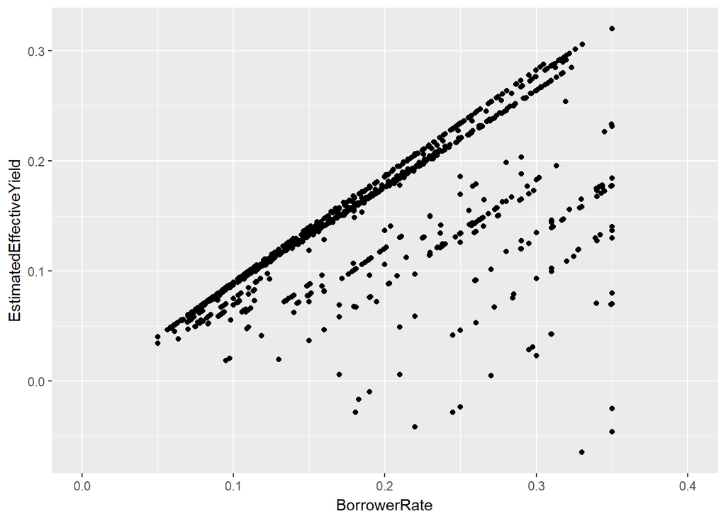

Point plots of borrower rate and APR vs estimated loss.

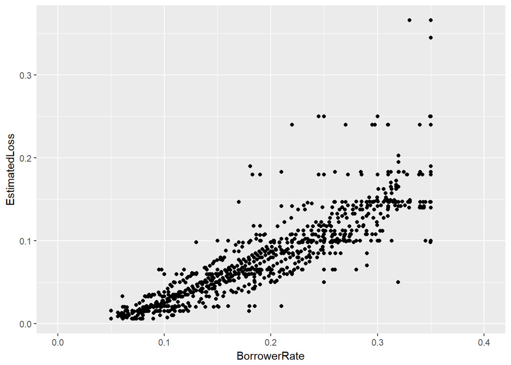

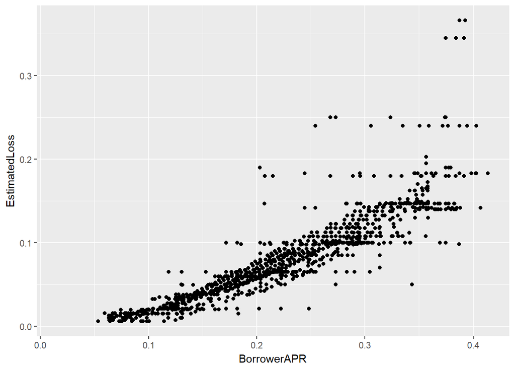

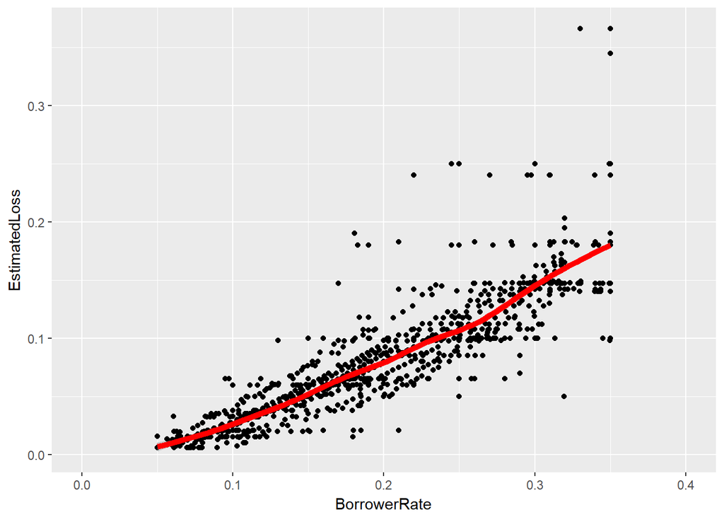

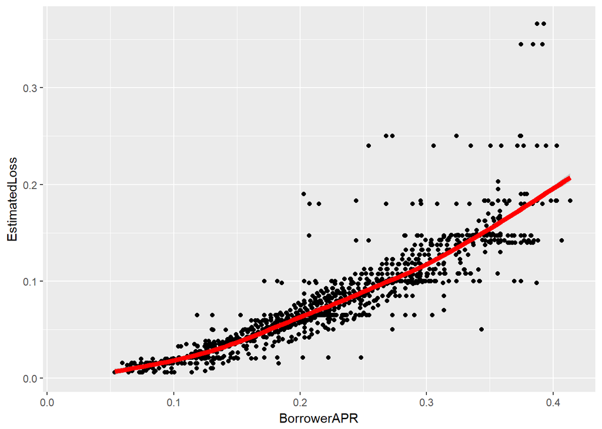

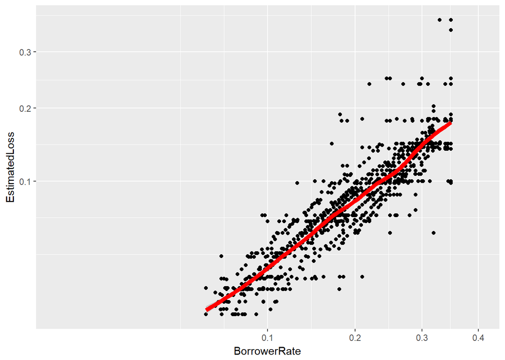

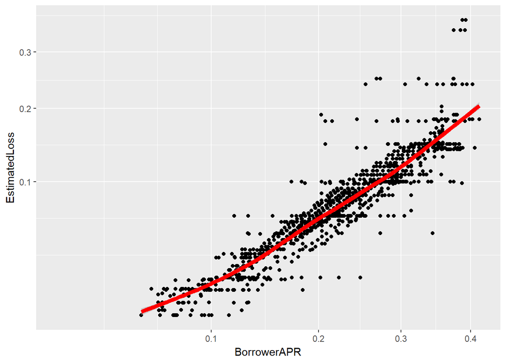

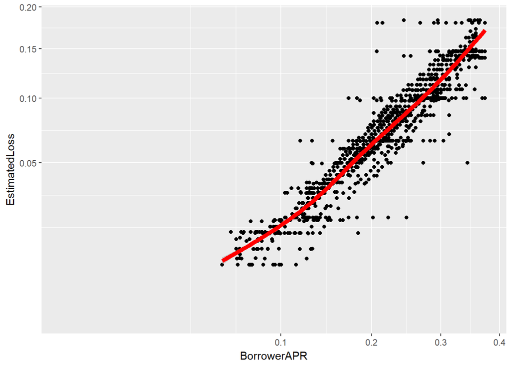

Point plots of loan amount vs monthly payment. Also a point plot of loan number vs listing number.

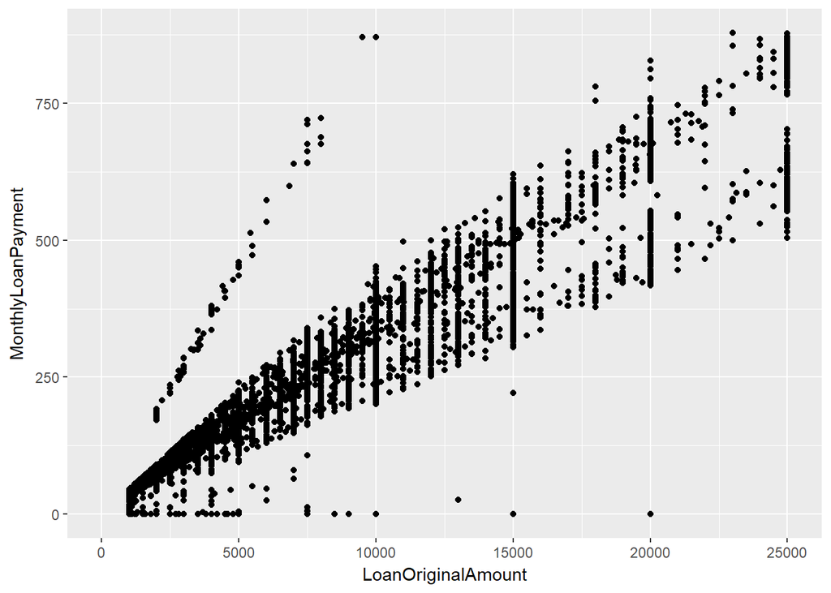

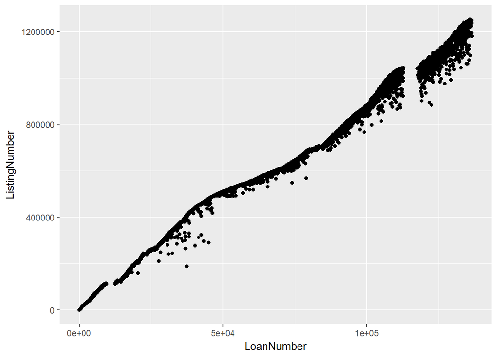

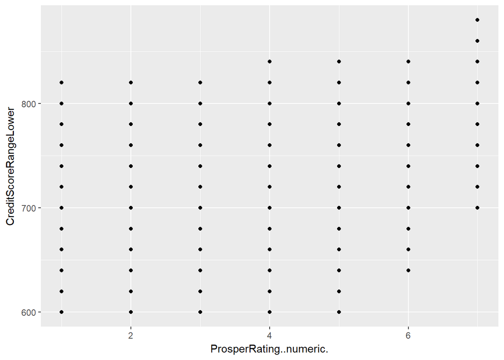

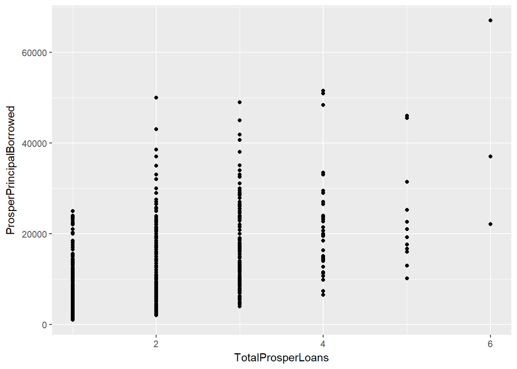

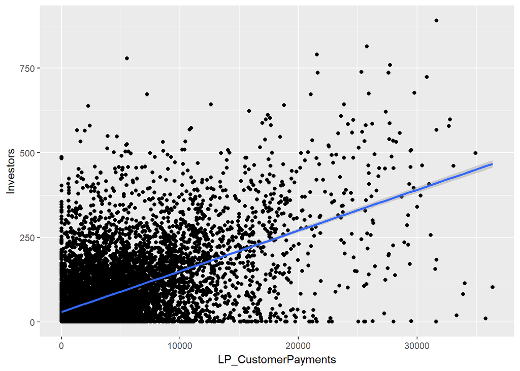

# Bivariate Analysis

Top .9 correlations to look at lender yield and loss vs borrower apr and rate original amount vs monthly payments loan number vs listing number

top .5 to .9 correlations credit score vs prosper rating num prosper principal vs prosper total loans loan currentdays delinquent vs lp-loss recomendation vs invest from friend investors vs lp costomer payments

### Talk about some of the relationships you observed in this part of the investigation. How did the feature(s) of interest vary with other features in the dataset?

### Did you observe any interesting relationships between the other features (not the main feature(s) of interest)?

### What was the strongest relationship you found?

# Multivariate Plots Section

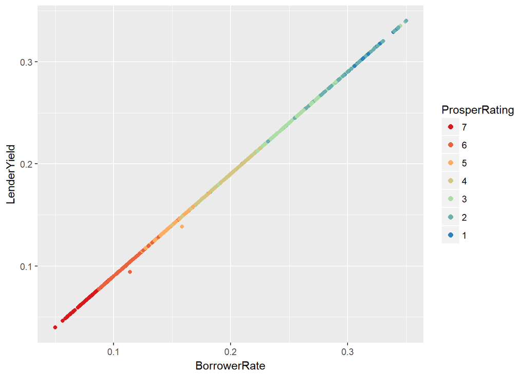

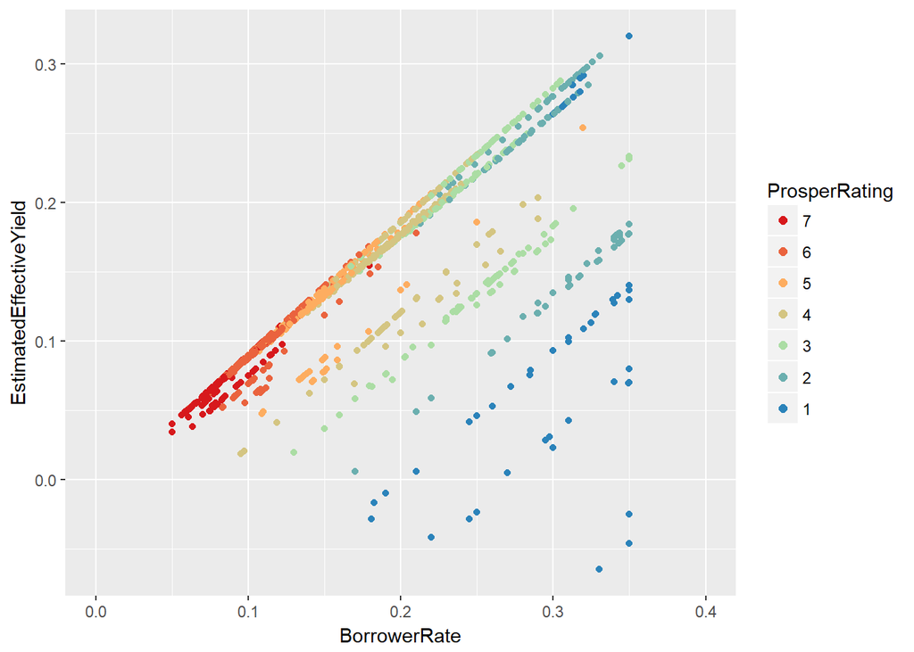

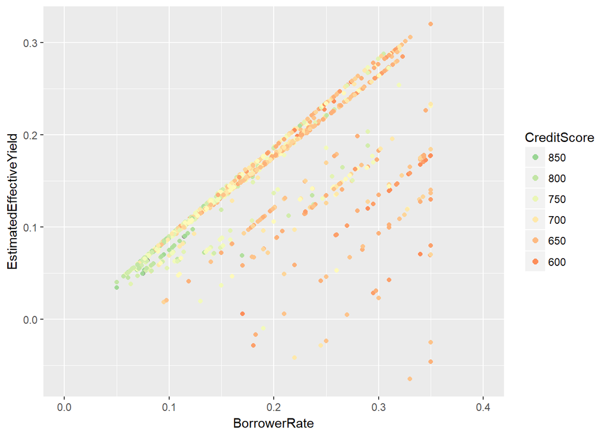

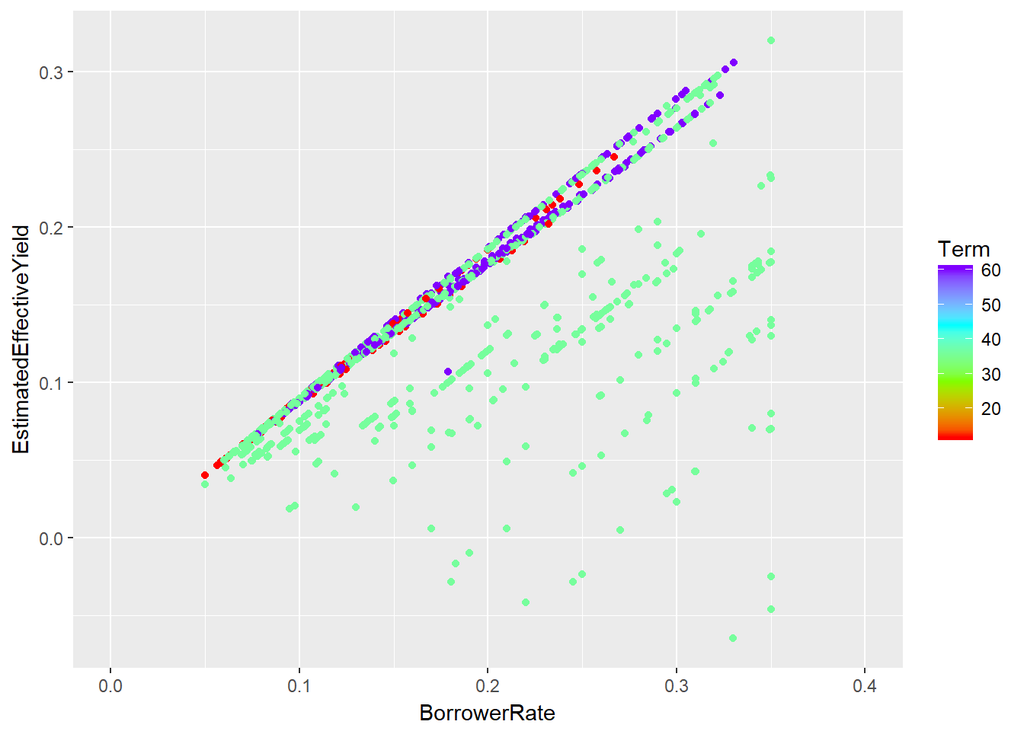